# About Gamma Regression

Tiago A. Marques

29 August 2023

# Introduction

In general, when thinking about modelling positive continuous values, most people except perhaps seasoned statisticians consider the Gaussian as a default. And there are many situations for which the Gaussian might be just enough, and you get the conventional lineart model and all the cool features that comes with it. However, if yout data corresponds to strictly positive numbers, you might happen to find that the Gaussian might not be enough. A particular aspect of the Gaussian model is that the variance is assumed to be constant, while you might have say variance increasing with the mean, or if you happen to make predictions which are negative when strictly values must be positive. Under such scenarios, Gamma regression can be a sensible alternative . However, when competing for popularity with the ubiquitous Gaussian regression, and to a couple discrete Generalize Linear Model (GLM) counterparts, like the Binomial (often logistic) and Poisson regressions, the Gamma gets relegated from the GLM podium. Together with the Beta regression, it corresponds to a lesser known family of distributions. While the Beta has been recently looked in detail by Douma & Weedon (2019), a similar paper is lacking regarding Gamma regression. This intends to be said paper illustrating the uses of the Gamma regression in an ecological context.

Continuous strictly positive data are ubiquitous in most sciences, in particular in ecology and evolution. Concentrations, weights, lengths, distances and speeds are just a handful of examples. These are often modeled with the standard linear model which assumed Gaussian residuals. If the mean response is not close to zero and the residuals are symmetric and homocedastic, that might be the preferred option. However, under many circumstances, especially for variables which have means close to zero, and hence are bounded close to their mean, the Gaussian will often prove unsuitable.

Most people when implementing regression models tend to choose a response family and stick with it without really looking at goodness of fit, but that choice might have implications on the inferences made. There are not many dedicated references to choosing amongts different families (but see Lindsey & Jones (1998) for an exception in the medical literature).

In a Gamma GLM the linear predictor gives us the mean of a Gamma for a set of covariates. Here we consider the Gamma regression and provide recommendations about its use. That is of course if we manage to understand it. As it turns out, there is more than meets the eye behind the Gamma and how to parametrize it for a GLM. Therefore, before looking at their use in a GLM setting, we describe the diferent parametrizations that might be considered.

# Gamma parametrizations

An interesting feature of the Gamma random variable is that the mean and variance are obtained directly from the parameters, as

$$E(X)=\mu=\alpha \beta$$

and

$$var(X)=\sigma^2\ = \alpha
\beta^2$$

Note that these parameters induce a distribution for which the variance is a function of the mean, since now

$$\sigma^2=\mu \beta$$

and therefore, for a given shape $\alpha$, the variance will be larger than the mean provided that $\beta>1$ and lower than the mean if $\beta<1$. Usually it is stated that for the Gamma the variance is larger than the mean, and while that might often be the case, and perhaps the most useful case in a GLM, the above shows that it should be stated the variance can be higher than the mean, but that property is not a necessary condition in a Gamma. In general, the variance $\sigma^2$ of a Gamma will be a function of its mean $\mu$, but one can actually force the variance to be constant irrespective of the mean, as will be shown below.

We can invert these expressions and represent the shape $\alpha$ and the scale $\beta$ as a function of the mean and the variance of the respective Gamma. We obtain the shape as

$$\alpha =
\frac{\mu^2}{\sigma^2}$$

and the scale as

$$\beta =
\frac{\sigma^2}{\mu}$$

An usual re-parameterization is made in terms of a rate parameter $\lambda$, which corresponds to the inverse of the scale parameter, where $\lambda=1/\beta$. Just as the scale and rate are the inverse of each other, another parameter might be considered in the Gamma, the dispersion parameter, or $\phi$, and this corresponds to the inverse of the shape parameter ($\alpha=1/\phi$). This allows the representation of the mean as

$$E(X)=\frac{\beta}{\phi}$$

and we can also represent the variance of the Gamma as

$$\sigma^2=\frac{\beta^2}{\phi}$$

which as before implies

$$\sigma^2=\mu \beta.$$

Yet another paramterization that is often considerered is referred to as the mean-shape parameterization (https://stats.stackexchange.com/questions/247624/dispersion-parameter-for-gamma-family).

Here, we can define the shape to be $\frac{1}{\phi}$ and the scale to be $\mu \phi$, which leads to a mean

$$E(X)=\mu$$

and variance

$$\sigma^2=\mu^2 \phi.$$

This latter parameterization is perhaps less familiar to researchers working with Gamma random variables, but it will be parameterization required for understanding a Gamma GLM. While the variance does not necessarily need to increase with the mean (e.g. $\mu<0$ and $\phi<0$), that might generically be the case and the most common case for Gamma GLMs.

# Simulating Gamma data

In practice, to simulate data from a Gamma with a given mean, as one would require if say for example one wanted either to (1) simulating data from a fitted GLM; or (2) to generate data to fit a GLM under a known reality scenario, one could actually envisage a few different approaches:

1. data where variance depends on the mean
2. data with constant variance
3. data where we define a constant dispersion (and hence the variance depends on the mean squared)

## Variance depends on the mean

For the former we define the mean $\mu$ and a dispersion parameter $\phi$, and then we set the shape parameter to be $\mu \phi$ and the scale parameter as $\frac{1}{\phi}$ we obtained the desired gamma, with mean $\mu$ and a variance of $\frac{\mu}{\phi}$. Note that this induces a mean-variance relation as a function of the dispersion parameter $\phi$, for a given mean (just as before we saw one such mean-variance relation as a function of $\beta$, for a given shape $\alpha$): the variance will be greater than the mean if $\phi<1$ and lower than the mean if $\phi>1$.

```r
#define the dispersion parameters for my example below
phi1 <- 0.2
phi2 <- 2
```

As a couple of illustrative examples, consider Gammas with a dispersion parameter either below or above one, that is $\phi_1$=0.2 and $\phi_2$=2, respectively.

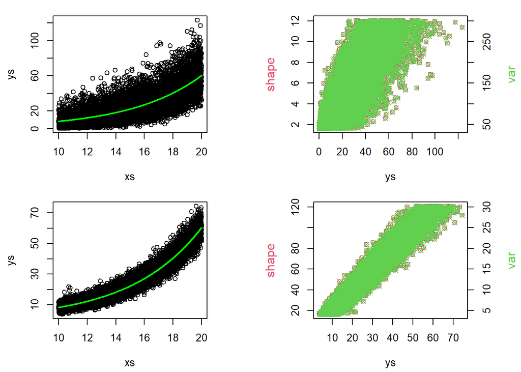

```r
par(mfrow=c(2,2),mar = c(4, 4, 1, 4) + 0.3)
#parameterization 1

#generate gamma data
set.seed(123)
# define limits for predictor
xsmin<- 10
xsmax<-20
#define sample size
n<-10000
#define number of points to predict
npred<- 500
#define points to predict later
xspreds<-seq(xsmin,xsmax,length=npred)
#generate predictor
xs<-runif(n,xsmin,xsmax)
#define intercept and slope for the libear predictor
int<-0.1
slope<-0.2
#generate mean value of the response
meang<-exp(int+slope*xs)

#generate responses, from dispersion = 0.2
ys<-rgamma(n,shape=meang*phi1,scale=1/phi1)
dat<- data.frame(weight=ys,length=xs)
#plot data
plot(xs,ys)
#add true line
points(xspreds,exp(int+slope*xspreds),type="l",col="green",lwd=2)

#shape and variance as a function of the mean, for dispersion=0.2
shape <- meang*phi1
var <- meang/phi1
# Draw first plot using axis y1
plot(ys, shape, pch = 1, col = 2,ylab="")
mtext("shape", side = 2, line = 3,col = 2)
# set parameter new=True for a new axis
par(new = TRUE)
# Draw second plot using axis y2
plot(ys, var, pch = 4, col = 3, axes = FALSE, xlab = "", ylab = "")
axis(side = 4, at = pretty(range(var)))
mtext("var", side = 4, line = 3,col = 3)

#parameterization 2

#dispersion=0.2
#generate gamma data
#generate responses
ys<-rgamma(n,shape=meang*phi2,scale=1/phi2)
dat<- data.frame(weight=ys,length=xs)
#plot data
plot(xs,ys)
#add true line
points(xspreds,exp(int+slope*xspreds),type="l",col="green",lwd=2)

#shape and variance as a function of the mean, for dispersion=2
shape <- meang*phi2
var <- meang/phi2
# Draw first plot using axis y1
par(mar = c(4, 4, 1, 4) + 0.3)
plot(ys, shape, pch = 1, col = 2,ylab="")
mtext("shape", side = 2, line = 3,col = 2)
# set parameter new=True for a new axis
par(new = TRUE)
# Draw second plot using axis y2
plot(ys, var, pch = 4, col = 3, axes = FALSE, xlab = "", ylab = "")
axis(side = 4, at = pretty(range(var)))
mtext("var", side = 4, line = 3,col = 3)
```

Note that by fixing the mean and the dispersion, a given mean can be obtained via a range of different shape and scale parameters. In this example, as the mean increases both the shape and the variance increase, but while on the first case ($\phi_1=0.2$, top row), since $\phi_1$<1, the variance is larger than the mean, on the second case ($\phi_2=2$, bottom row) since $\phi_2$>1, the variance is lower than the mean.

## Constant variance

Given what I struggled with the gamma implementation for the sperm whale cue rate model, I actually arrived at another possible parameterization for the Gamma: one where the variance is not dependent on the mean.

The way to parameterize a GLM might be to define the mean $\mu$ and the $\sigma^2$, resulting in dynamic values (since they depend now on both $\mu$ and $\sigma^2$) for $\alpha$ (shape) and $\beta$ (rate) parameters $\frac{\mu^2}{\sigma^2}$ and $\frac{\mu}{\sigma^2}$, respectively.

Using this parameterization, we end up with a gamma in which the variance is actually constant, hence it does not depend on the mean.

```r
#generate gamma data
set.seed(123)
#define the variance parameter
vari <- 0.2
# define limits for predictor
xsmin<- 10
xsmax<-20
#define sample size
n<-10000
#define number of pointsto predict
npred<- 500
#define poiunt to predict later
xspreds<-seq(xsmin,xsmax,length=npred)
#generate predictor
xs<-runif(n,xsmin,xsmax)
#define intercept and slope for the libear predictor
int<-0.1
slope<-0.2
#generate mean value of the response
meang<-exp(int+slope*xs)
#generate responses
ys<-rgamma(n,shape=meang^2/vari,rate=meang/vari)

dat<- data.frame(weight=ys,length=xs)

#get the shape and rate parameters
shape <- ys^2/vari
rate <- ys/vari
```

Look at the data

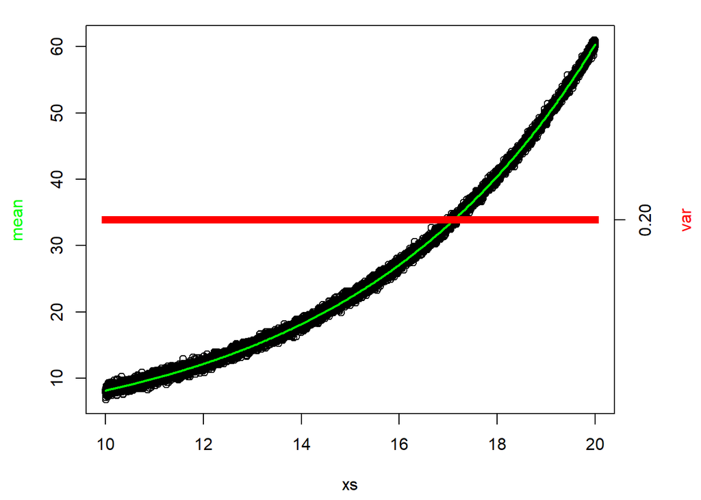

```r
par(mfrow=c(1,1))

par(mar = c(4, 4, 1, 4) + 0.3)
#plot data
# Draw first plot using axis y1
plot(xs,ys,xlab="xs",ylab="")
#add true line
points(xspreds,exp(int+slope*xspreds),type="l",col="green",lwd=2)

mtext("mean", side = 2, line = 3,col = "green")

# set parameter new=True for a new axis
par(new = TRUE)

# Draw second plot using axis y2
plot(xs, shape*(1/rate)^2, pch = 15, col = "red", axes = FALSE, xlab = "", ylab = "")

axis(side = 4, at = pretty(range(0.1,0.3)))
mtext("var", side = 4, line = 3,col = "red")
```

As noted above, since the variance is kept constant, the shape and the rate parameters will vary as a function of the mean

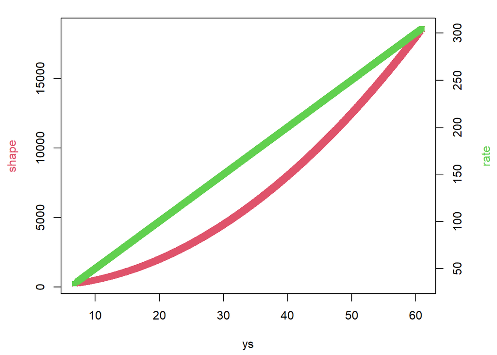

```r
shape <- ys^2/vari
rate <- ys/vari
#plot(ys,shape)
#points(ys,rate)

# Draw first plot using axis y1
par(mar = c(4, 4, 1, 4) + 0.3)
plot(ys, shape, pch = 13, col = 2,ylab="")

mtext("shape", side = 2, line = 3,col = 2)

# set parameter new=True for a new axis
par(new = TRUE)

# Draw second plot using axis y2
plot(ys, rate, pch = 15, col = 3, axes = FALSE, xlab = "", ylab = "")

axis(side = 4, at = pretty(range(rate)))
mtext("rate", side = 4, line = 3,col = 3)
```

This is NOT, however, how we parameterize the Gamma in a GLM.

## Variance depends on mean squared

To formulate a gamma GLM, we borrow on a gamma property shared by the lognormal. When the shape parameter is held constant while the scale parameter is varied, the variance is proportional to mean-squared. Note this also implies a constant coefficient of variation (https://stats.stackexchange.com/questions/67547/when-to-use-gamma-glms). Therefore, behind a gamma GLM we have a mean-shape parameterization, where the variance increases with mean squared and there is a constant dispersion (which is the same as to say a constant shape) parameter.

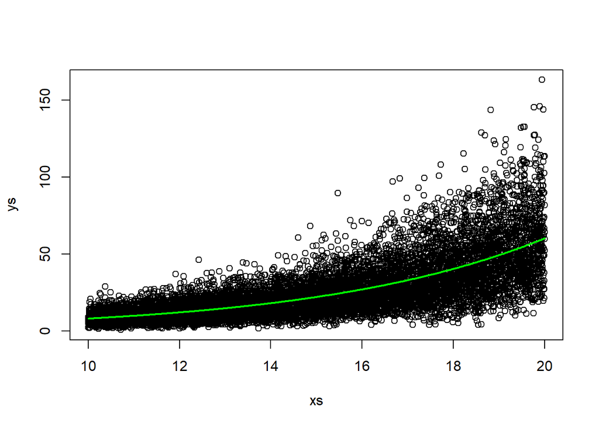

```r
# parameterization 3

#dispersion=0.2
#generate gamma data
#generate responses
ys<-rgamma(n,shape=1/phi1,scale=meang*phi1)
dat<- data.frame(weight=ys,length=xs)
#plot data
plot(xs,ys)
#add true line
points(xspreds,exp(int+slope*xspreds),type="l",col="green",lwd=2)
```

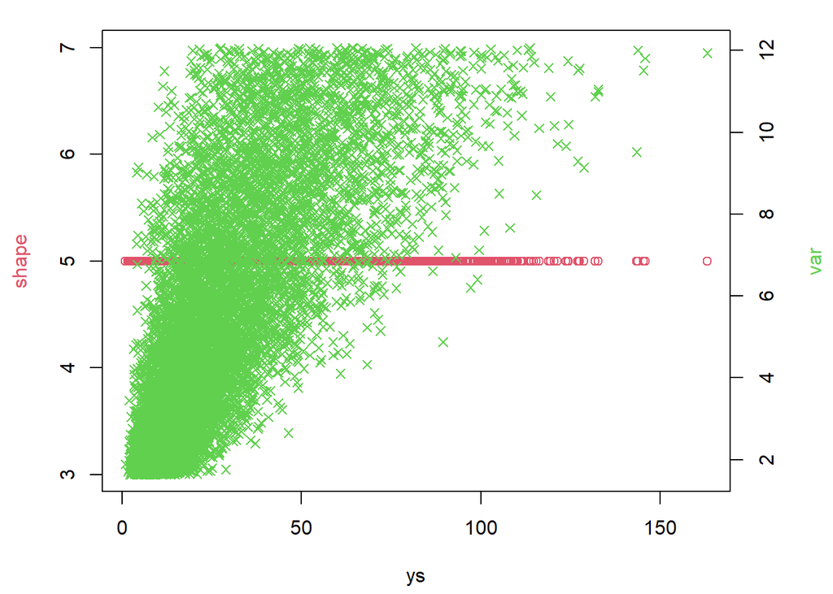

```r
#shape and variance as a function of the mean, for dispersion=2
shape <- rep(1/phi1,times=length(ys))
var <- meang*phi1
# Draw first plot using axis y1
par(mar = c(4, 4, 1, 4) + 0.3)
plot(ys, shape, pch = 1, col = 2,ylab="")
mtext("shape", side = 2, line = 3,col = 2)
# set parameter new=True for a new axis
par(new = TRUE)
# Draw second plot using axis y2
plot(ys, var, pch = 4, col = 3, axes = FALSE, xlab = "", ylab = "")
axis(side = 4, at = pretty(range(var)))
mtext("var", side = 4, line = 3,col = 3)
```

# Using a Gamma GLM to fit a Gamma to data

In a Gamma GLM we will have the response $X$ with a Gamma distribution and, assuming a single predictor for notation simplicity without loss of generality,

which also means that

$$\mu = \eta^{-1}(\beta_0+\beta_1 x_1)$$

```r
m<-4
v<-10
```

Based on observations of a Gamma, we can estimate the parameters of a gamma distribution, which is akin to fitting a gamma distribution to the data, using the `glm` function. This is essentially a regression model without any independent covariates. Note that while the mean is estimated correctly via the `glm` maximum likelihood, the reported estimated dispersion in the `glm` output in not a maximum likelihood estimate (MLE). Nonetheless, the library `MASS` has a couple of functions that can be used over a GLM object to obtain MLE’s for said parameter:

- `gamma.shape` - estimates the shape parameter
- `gamma.dispersion` - estimates the inverse of the shape parameter, that is, the dispersion parameter

An example follows. Suppose we have a gamma with mean=4 and variance=10. Given the above, that corresponds to a shape of 1.6, a scale of 2.5, a rate of 0.4 and a dispersion of 0.62.

```r
#define sample size for simulation
n<-5000
```

We simulate data, in this case 5000 observations, fit the model and recover the parameters from `glm`. Note we consider here the `glm` link to be the identity

```r
set.seed(124)

gammas<-rgamma(n,shape=m^2/v,scale=v/m)
m1<-glm(gammas~1,family=Gamma(link="identity"))
sm1<-summary(m1)
sm1
```

```
##
## Call:
## glm(formula = gammas ~ 1, family = Gamma(link = "identity"))
##
## Coefficients:
##             Estimate Std. Error t value            Pr(>|t|)
## (Intercept)   4.0489     0.0454   89.18 <0.0000000000000002 ***
## ---
## Signif. codes:  0 '***' 0.001 '**' 0.01 '*' 0.05 '.' 0.1 ' ' 1
##
## (Dispersion parameter for Gamma family taken to be 0.6287047)
##
##     Null deviance: 3444.4  on 4999  degrees of freedom
## Residual deviance: 3444.4  on 4999  degrees of freedom
## AIC: 23436
##
## Number of Fisher Scoring iterations: 3
```

We compare true values and estimated values in the table below.

```r
#making a small printable data.frame for kable
comp<-data.frame(parameter=c("mean","variance","shape","scale","dispersion","rate"),true=NA,estimated=NA)
comp[,2]<-c(m,v,m^2/v,v/m,v/m^2,m/v)
comp[,3]<-c(sm1$coefficients[1],sum(residuals(m1, type = "response")^2)/sm1$df.residual,as.numeric(gamma.shape(m1))[1],sm1$coefficients[1]/(1/sm1$dispersion),gamma.dispersion(m1),(1/sm1$dispersion)/sm1$coefficients[1])
kable(comp,digits=2)
```

| parameter | true | estimated |
| --- | --- | --- |
| mean | 4.00 | 4.05 |
| variance | 10.00 | 10.31 |
| shape | 1.60 | 1.60 |
| scale | 2.50 | 2.55 |
| dispersion | 0.62 | 0.63 |
| rate | 0.40 | 0.39 |

As expected given the sample size, all the parameter estimates are quite close to their true values.

# Fitting gamma models

We start by simulating data from a gamma model, with a log link, and then do the same with an inverse link. We compare the models fitted considering the correct link function and several alternatives (link functions used: log, inverse, identity).

Note that the relation between the mean valueof the response $Y$ and the linear predictor $X$ are, for each of the link functions:

- $\mathbf E(y|x)=exp(a+bx)$, in the case of the log link
- $\mathbf E(y)=\frac{1}{a+bx}$ in the case of the inverse
- $\mathbf E(y)=a+bx$, in the case of the identity

Note the formulation for the inverse link might induce confusion with the interpretation of the parameters in a Gamma GLM. An estimated negative value for the slope induces a positive relation between the predictor and the response, and vice versa.

## Log-link

We generate data from a log-link, and we then fit models with the log-link, but also the inverse and identity links for comparison.

Simulate data, via first option

```r
#generate gamma data
set.seed(123)
#define the dispersion parameter
p1 <- 0.2
# define limits for predictor
xsmin<- 10
xsmax<-20
#define sample size
n<-10000
#define number of pointsto predict
npred<- 500
#define poiunt to predict later
xspreds<-seq(xsmin,xsmax,length=npred)
#generate predictor
xs<-runif(n,xsmin,xsmax)
#define intercept and slope for the libear predictor
int<-0.1
slope<-0.2
#generate mean value of the response
meang<-exp(int+slope*xs)
#generate responses
ys<-rgamma(n,shape=1/p1,scale=meang*p1)

dat<- data.frame(weight=ys,length=xs)
```

Look at the data

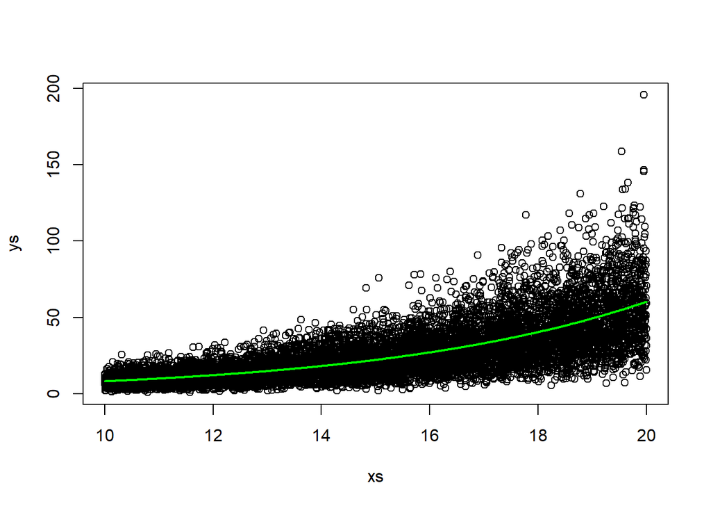

```r
#plot data
plot(xs,ys)
#add true line
points(xspreds,exp(int+slope*xspreds),type="l",col="green",lwd=2)
```

Fit different models, the correct link, the log link

```r
#fit gamma
glm1<-glm(weight~length,family=Gamma(link="log"),data=dat)
summary(glm1)
```

```
##
## Call:
## glm(formula = weight ~ length, family = Gamma(link = "log"),
##     data = dat)
##
## Coefficients:
##             Estimate Std. Error t value             Pr(>|t|)
## (Intercept) 0.103972   0.023566   4.412            0.0000104 ***
## length      0.199362   0.001546 128.988 < 0.0000000000000002 ***
## ---
## Signif. codes:  0 '***' 0.001 '**' 0.01 '*' 0.05 '.' 0.1 ' ' 1
##
## (Dispersion parameter for Gamma family taken to be 0.1963257)
##
##     Null deviance: 5198.1  on 9999  degrees of freedom
## Residual deviance: 2040.1  on 9998  degrees of freedom
## AIC: 72579
##
## Number of Fisher Scoring iterations: 4
```

Note that we simulated data considering a $\beta_0$, $\beta_1$ and dispersion parameter for the gamma to be respectively 0.1, 0.2 and 0.2 and we estimate these to be 0.104 (se=0.024), 0.199 (se=0.002) and 0.196, respectively. These results are quite close to the truth, as expected given the large sample size (n=10000).

What would happen if we fitted with the wrong link function? Suppose we consider the (canonical for the Gamma) inverse link function. The we get this

```r
#fit gamma, INVERSE
glm2<-glm(weight~length,family=Gamma(link="inverse"),data=dat)
summary(glm2)
```

```
##
## Call:
## glm(formula = weight ~ length, family = Gamma(link = "inverse"),
##     data = dat)
##
## Coefficients:
##                Estimate  Std. Error t value            Pr(>|t|)
## (Intercept)  0.16568435  0.00124680   132.9 <0.0000000000000002 ***
## length      -0.00767906  0.00006915  -111.1 <0.0000000000000002 ***
## ---
## Signif. codes:  0 '***' 0.001 '**' 0.01 '*' 0.05 '.' 0.1 ' ' 1
##
## (Dispersion parameter for Gamma family taken to be 0.2203788)
##
##     Null deviance: 5198.1  on 9999  degrees of freedom
## Residual deviance: 2243.1  on 9998  degrees of freedom
## AIC: 73561
##
## Number of Fisher Scoring iterations: 5
```

We estimate the parameters to be 0.166 (se=0.001), -0.008 (se=0) and 0.22, respectively. Note that even if the predicted function will try to fit the data, the parameter estimates become quite different from the true values, except for the estimated dispersion. In particular, notice how the coeficient associated with the predictor has changed signs!

If one considered the identity link instead

```r
#fit gamma, IDENTITY
glm3<-glm(weight~length,family=Gamma(link="identity"),data=dat,start=c(0.1,0.2))
summary(glm3)
```

```
##
## Call:
## glm(formula = weight ~ length, family = Gamma(link = "identity"),
##     data = dat, start = c(0.1, 0.2))
##
## Coefficients:
##              Estimate Std. Error t value            Pr(>|t|)
## (Intercept) -32.07869    0.41892  -76.57 <0.0000000000000002 ***
## length        3.81051    0.03415  111.57 <0.0000000000000002 ***
## ---
## Signif. codes:  0 '***' 0.001 '**' 0.01 '*' 0.05 '.' 0.1 ' ' 1
##
## (Dispersion parameter for Gamma family taken to be 0.219673)
##
##     Null deviance: 5198.1  on 9999  degrees of freedom
## Residual deviance: 2234.1  on 9998  degrees of freedom
## AIC: 73519
##
## Number of Fisher Scoring iterations: 9
```

We estimate the parameters to be -32.079 (se=0.419), 3.811 (se=0.034) and 0.22, respectively. As for the inverse-link, the parameter estimates become quite different from the true values, except still for the estimated dispersion.

Look at all the different models fitted considering different link-functions against the true data generating model

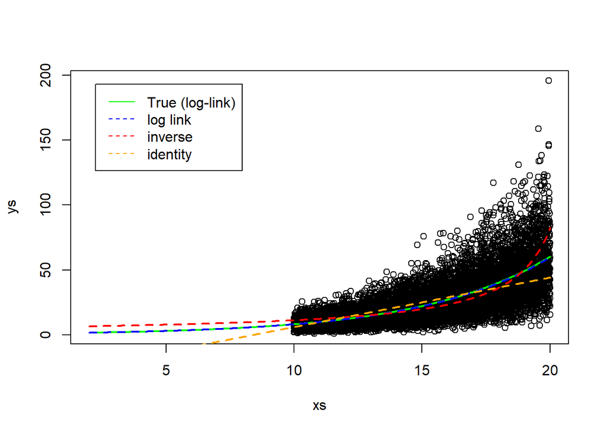

```r
plot(xs,ys,xlim=c(2,20))
xspreds<-seq(2,xsmax,length=npred)
#add true line
points(xspreds,exp(int+slope*xspreds),type="l",col="green",lwd=2)
# CORRECT LOG LINK
preds<-predict(glm1,newdata = data.frame(length=xspreds),type="response")
#add fitted values
points(xspreds,preds,type="l",col="blue",lwd=2,lty=2)
# INVERSE LINK
preds<-predict(glm2,newdata = data.frame(length=xspreds),type="response")
#add fitted values
points(xspreds,preds,type="l",col="red",lwd=2,lty=2)
# IDENTITY LINK
preds<-predict(glm3,newdata = data.frame(length=xspreds),type="response")
#add fitted values
points(xspreds,preds,type="l",col="orange",lwd=2,lty=2)
legend("topleft",legend=c("True (log-link)","log link","inverse","identity"),col=c("green","blue","red","orange"),lty=c(1,2,2,2),inset=0.05)
```

Note the above image illustrates clearly that it is the link function, not the distribution family, that constrains predictions to be strictly positive. Using the identity link we can easily get negative predictions : for say `xs`=2, we predict 1.65, 6.65 and -24.46 for the log, the inverse and the identity link functions, respectively.

Another thought comes to mind. The link function considered induces quite strong constraints on the predictions. Above, the predictions from the inverse link-function are far off compared to the observed data, overestimating the mean value for large values of the predictor, while the opposite happens for the identity link.

The AIC for the models are

```r
AIC(glm1,glm2,glm3)
```

```
##      df      AIC
## glm1  3 72578.75
## glm2  3 73561.01
## glm3  3 73519.19
```

and reassuringly, if we chose the best model based on AIC, the true model would be the model selected by far.

## Inverse link 1

When we consider an inverse link for the gamma, we must be quite careful with the choice of parameters, as some lead to inadmissible values. That in itself is a matter for concern, because it hints for the fact that we could have issues when predicting?

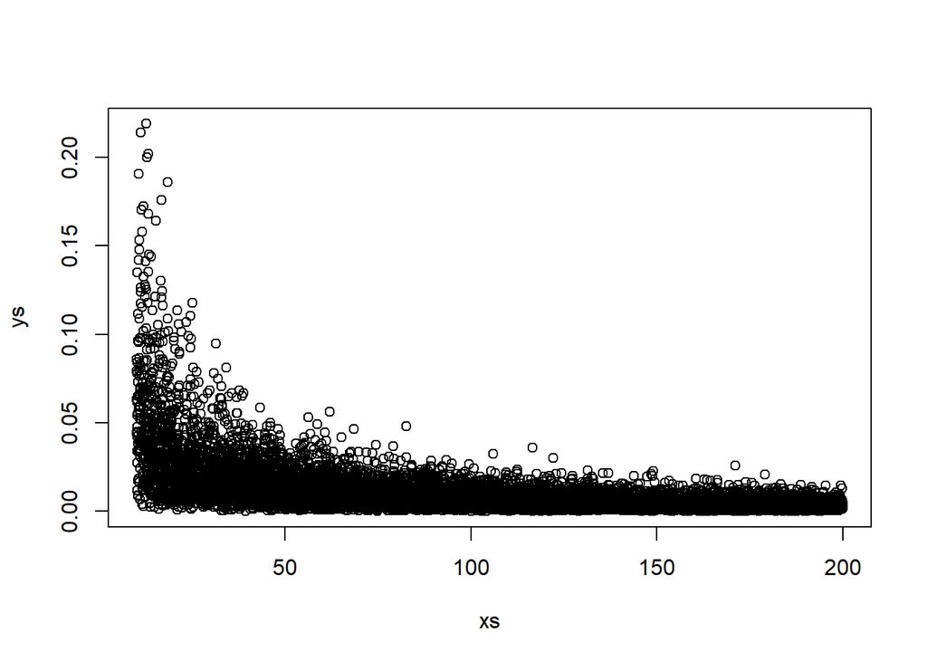

```r
#generate gamma data
set.seed(123)
#define the dispersion parameter
p1 <- 0.5
# define limits for predictor
xsmin<- 10
xsmax<-200
#define sample size
n<-10000
#define number of points to predict
npred<- 500
#generate predictor
xs<-runif(n,xsmin,xsmax)
#define intercept and slope for the linear predictor
int<-1.1
slope<-1.4
#generate mean value of the response
meang<- (1/(int+slope*xs))
#generate responses
ys<-rgamma(n,shape=1/p1,scale=meang*p1)

dat<- data.frame(weight=ys,length=xs)
#plot data
xspreds<-seq(xsmin,xsmax,length=npred)
plot(xs,ys)
```

```r
#fit gamma
glm1.i<-glm(weight~length,family=Gamma(link="inverse"),data=dat)
summary(glm1.i)
```

```
##
## Call:
## glm(formula = weight ~ length, family = Gamma(link = "inverse"),
##     data = dat)
##
## Coefficients:
##             Estimate Std. Error t value            Pr(>|t|)
## (Intercept)  1.20568    0.65588   1.838              0.0661 .
## length       1.40990    0.01429  98.654 <0.0000000000000002 ***
## ---
## Signif. codes:  0 '***' 0.001 '**' 0.01 '*' 0.05 '.' 0.1 ' ' 1
##
## (Dispersion parameter for Gamma family taken to be 0.5001811)
##
##     Null deviance: 11228.4  on 9999  degrees of freedom
## Residual deviance:  5372.1  on 9998  degrees of freedom
## AIC: -78502
##
## Number of Fisher Scoring iterations: 6
```

Here we consider an example where the intercept was 1.1, the slope was 1.4 and the dispersions was 0.5. Note how the estimated values of the coefficients of the linear predictor is positive, but the effect of `xs` on the response is decreasing. This actually means care is needed when interpreting the values. I have seen folks stating as x increases y increases because they fitted a Gamma (with the default link, which is the inverse), when it should be the opposite (would be great to find an example in a paper).

Considering the true link function all the parameters are, not surprisingly, correctly estimated. The estimated dispersion parameter matches perfectly with the true value (estimated at 0.5 vs. true value of 0.5).

What happens when we consider a different link function? We experiment first with the log-link

```r
#fit gamma, INVERSE
glm2<-glm(weight~length,family=Gamma(link="log"),data=dat)
summary(glm2)
```

```
##
## Call:
## glm(formula = weight ~ length, family = Gamma(link = "log"),
##     data = dat)
##
## Coefficients:
##               Estimate Std. Error t value            Pr(>|t|)
## (Intercept) -3.4854402  0.0170576 -204.33 <0.0000000000000002 ***
## length      -0.0123851  0.0001447  -85.59 <0.0000000000000002 ***
## ---
## Signif. codes:  0 '***' 0.001 '**' 0.01 '*' 0.05 '.' 0.1 ' ' 1
##
## (Dispersion parameter for Gamma family taken to be 0.6212998)
##
##     Null deviance: 11228.4  on 9999  degrees of freedom
## Residual deviance:  5957.7  on 9998  degrees of freedom
## AIC: -77372
##
## Number of Fisher Scoring iterations: 7
```

and then with the identity link.

```r
#fit gamma, IDENTITY
glm3<-glm(weight~length,family=Gamma(link="identity"),data=dat,start=c(0.1,0.2))
summary(glm3)
```

```
##
## Call:
## glm(formula = weight ~ length, family = Gamma(link = "identity"),
##     data = dat, start = c(0.1, 0.2))
##
## Coefficients:
##                 Estimate   Std. Error t value            Pr(>|t|)
## (Intercept)  0.018720236  0.000240461   77.85 <0.0000000000000002 ***
## length      -0.000082878  0.000001434  -57.80 <0.0000000000000002 ***
## ---
## Signif. codes:  0 '***' 0.001 '**' 0.01 '*' 0.05 '.' 0.1 ' ' 1
##
## (Dispersion parameter for Gamma family taken to be 0.8995891)
##
##     Null deviance: 11228.4  on 9999  degrees of freedom
## Residual deviance:  7005.9  on 9998  degrees of freedom
## AIC: -75583
##
## Number of Fisher Scoring iterations: 25
```

In particular, a number of warnings (muted in the output) are generated during model fitting with the identity link, possibly indicating that the model is making inadmissible predictions. Comparing all the results, we observe something analogous to what we found before.

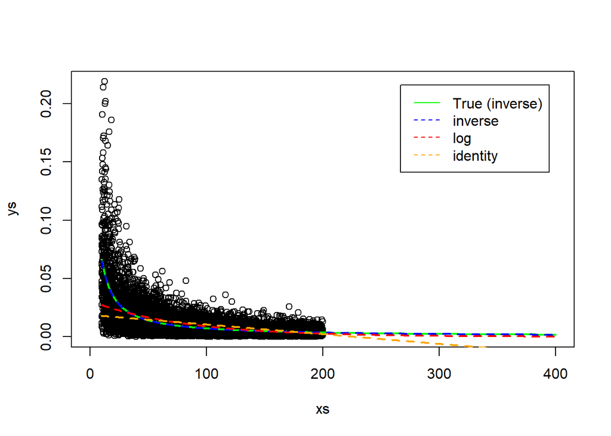

```r
plot(xs,ys,xlim=c(0,400))
#plot data
xspreds<-seq(xsmin,400,length=npred)
#add true line
points(xspreds,(1/(int+slope*xspreds)),type="l",col="green",lwd=2)

preds<-predict(glm1.i,newdata = data.frame(length=xspreds),type="response")
#add fitted values
points(xspreds,preds,type="l",col="blue",lwd=2,lty=2)
# IDENTITY LINK
preds<-predict(glm2,newdata = data.frame(length=xspreds),type="response")
#add fitted values
points(xspreds,preds,type="l",col="red",lwd=2,lty=2)
# IDENTITY LINK
preds<-predict(glm3,newdata = data.frame(length=xspreds),type="response")
#add fitted values
points(xspreds,preds,type="l",col="orange",lwd=2,lty=2)
legend("topright",legend=c("True (inverse)","inverse","log","identity"),col=c("green","blue","red","orange"),lty=c(1,2,2,2),inset=0.05)
```

Considering the wrong link functions, the estimated dispersion parameter also bears no resemblance with the true value, estimated at 0.621 for the log link and 0.9 for the identity link vs. true value of 0.5 (recall from above that we estimated the dispersion parameters to be 0.5 for the true inverse link). Therefore, like for the log-link function generated data, here for the inverse link the estimated dispersion changes depending on the link function considered. The same comment as above applies: the link function considered induces quite strong constraints on the predictions.

## Inverse link 2

When we consider still an inverse link for the gamma, but with the response being an increasing function of the predictor

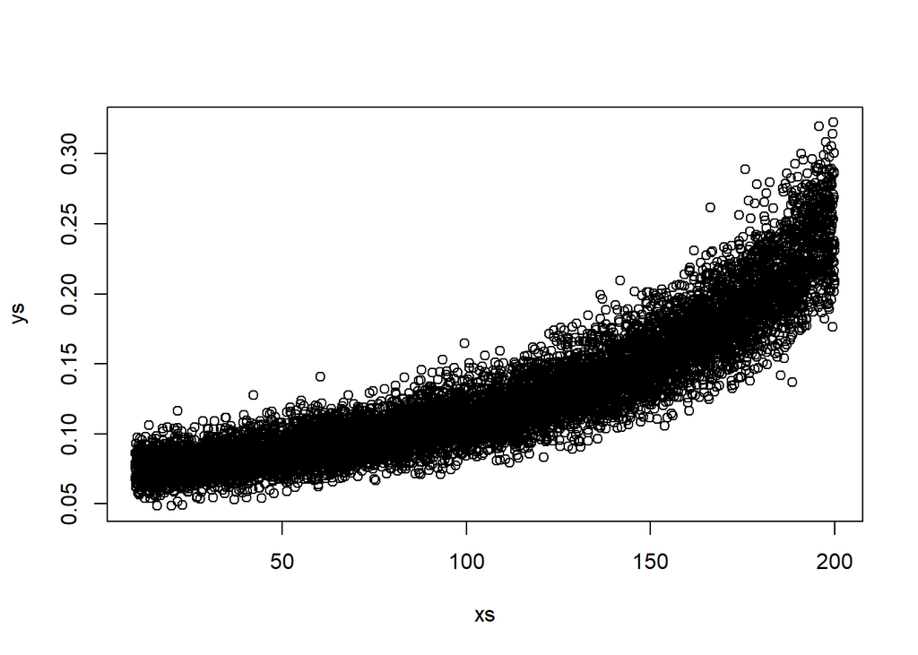

```r
#generate gamma data
set.seed(123)
#define the dispersion parameter
p1 <- 0.015
# define limits for predictor
xsmin<- 10
xsmax<-200
#define sample size
n<-10000
#define number of points to predict
npred<- 500
#generate predictor
xs<-runif(n,xsmin,xsmax)
#define intercept and slope for the linear predictor
int<-14
slope<--0.05
#generate mean value of the response
meang<- (1/(int+slope*xs))
#generate responses
ys<-rgamma(n,shape=1/p1,scale=meang*p1)

dat<- data.frame(weight=ys,length=xs)
#plot data
xspreds<-seq(xsmin,xsmax,length=npred)
plot(xs,ys)
```

```r
#fit gamma
glm1.i<-glm(weight~length,family=Gamma(link="inverse"),data=dat)
summary(glm1.i)
```

```
##
## Call:
## glm(formula = weight ~ length, family = Gamma(link = "inverse"),
##     data = dat)
##
## Coefficients:
##               Estimate Std. Error t value            Pr(>|t|)
## (Intercept) 14.0203778  0.0270663   518.0 <0.0000000000000002 ***
## length      -0.0500858  0.0001812  -276.4 <0.0000000000000002 ***
## ---
## Signif. codes:  0 '***' 0.001 '**' 0.01 '*' 0.05 '.' 0.1 ' ' 1
##
## (Dispersion parameter for Gamma family taken to be 0.01482972)
##
##     Null deviance: 1318.12  on 9999  degrees of freedom
## Residual deviance:  148.74  on 9998  degrees of freedom
## AIC: -56216
##
## Number of Fisher Scoring iterations: 4
```

Here we consider an example where the intercept was 14, the slope was -0.05 and the dispersion was 0.015. Note how the value of the slope coefficient of the linear predictor is the inverse (negative) of the trend (positive, y increases with x). This actually means care is needed when interpreting the output of a Gamma with the canonical link function. I have seen folks stating as x increases y increases because they fitted a Gamma (with the default link, which is the inverse), when it should be the opposite (would be great to find an example in a paper). While in a univariate context this would be hard to imagine, since most people would actually plot the data and hence see there was something off with the interpretation of the coefficients, in the case of multiple regression with several explanatory covariates, where plotting is harder, this could happen and incorrect inferences reported based on the sign of the coefficients.

```r
#fit gamma, INVERSE
glm2<-glm(weight~length,family=Gamma(link="log"),data=dat)
summary(glm2)
```

```
##
## Call:
## glm(formula = weight ~ length, family = Gamma(link = "log"),
##     data = dat)
##
## Coefficients:
##                Estimate  Std. Error t value            Pr(>|t|)
## (Intercept) -2.75458598  0.00289077  -952.9 <0.0000000000000002 ***
## length       0.00608646  0.00002452   248.2 <0.0000000000000002 ***
## ---
## Signif. codes:  0 '***' 0.001 '**' 0.01 '*' 0.05 '.' 0.1 ' ' 1
##
## (Dispersion parameter for Gamma family taken to be 0.01784394)
##
##     Null deviance: 1318.12  on 9999  degrees of freedom
## Residual deviance:  177.68  on 9998  degrees of freedom
## AIC: -54434
##
## Number of Fisher Scoring iterations: 4
```

```r
#fit gamma, IDENTITY
glm3<-glm(weight~length,family=Gamma(link="identity"),data=dat,start=c(0.1,0.2))
summary(glm3)
```

```
##
## Call:
## glm(formula = weight ~ length, family = Gamma(link = "identity"),
##     data = dat, start = c(0.1, 0.2))
##
## Coefficients:
##                Estimate  Std. Error t value            Pr(>|t|)
## (Intercept) 0.056091464 0.000302332   185.5 <0.0000000000000002 ***
## length      0.000671431 0.000003469   193.6 <0.0000000000000002 ***
## ---
## Signif. codes:  0 '***' 0.001 '**' 0.01 '*' 0.05 '.' 0.1 ' ' 1
##
## (Dispersion parameter for Gamma family taken to be 0.02553835)
##
##     Null deviance: 1318.12  on 9999  degrees of freedom
## Residual deviance:  248.41  on 9998  degrees of freedom
## AIC: -51071
##
## Number of Fisher Scoring iterations: 7
```

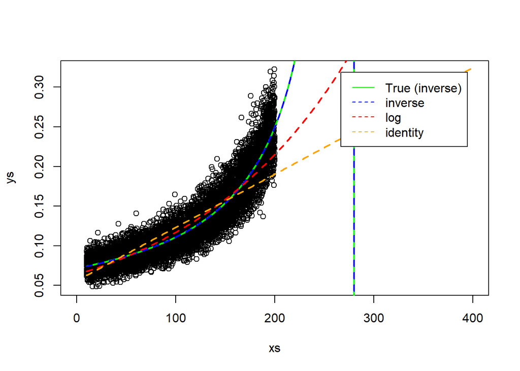

```r
plot(xs,ys,xlim=c(0,400))
#plot data
xspreds<-seq(xsmin,400,length=npred)
#add true line
points(xspreds,(1/(int+slope*xspreds)),type="l",col="green",lwd=2)

preds<-predict(glm1.i,newdata = data.frame(length=xspreds),type="response")
#add fitted values
points(xspreds,preds,type="l",col="blue",lwd=2,lty=2)
# IDENTITY LINK
preds<-predict(glm2,newdata = data.frame(length=xspreds),type="response")
#add fitted values
points(xspreds,preds,type="l",col="red",lwd=2,lty=2)
# IDENTITY LINK
preds<-predict(glm3,newdata = data.frame(length=xspreds),type="response")
#add fitted values
points(xspreds,preds,type="l",col="orange",lwd=2,lty=2)
legend("topright",legend=c("True (inverse)","inverse","log","identity"),col=c("green","blue","red","orange"),lty=c(1,2,2,2),inset=0.05)
```

The same comment as above applies: the link function considered induces quite strong constraints on the predictions.

Here’s an example

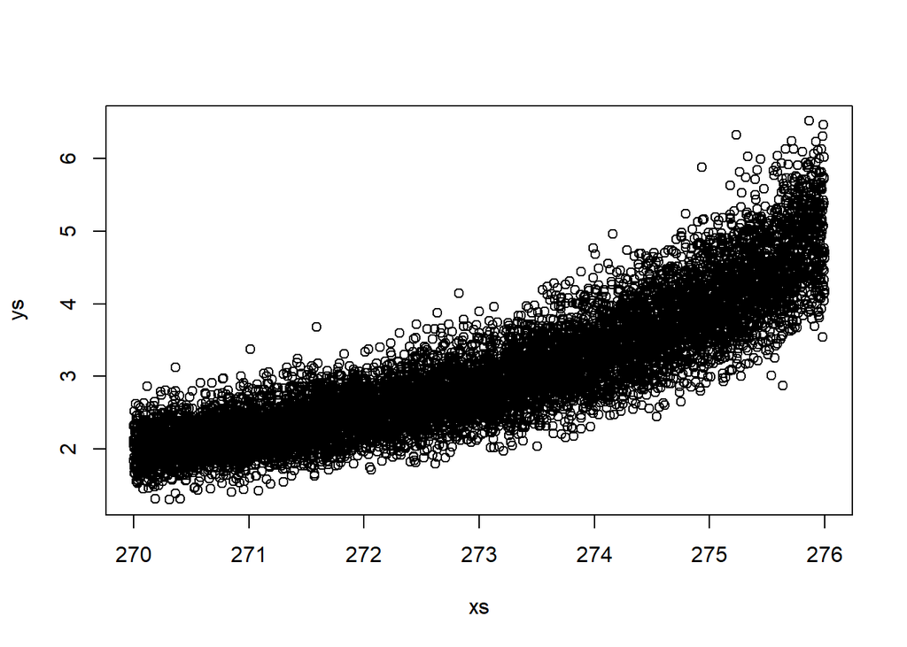

```r
#generate gamma data
set.seed(123)
#define the dispersion parameter
p1 <- 0.015
# define limits for predictor
xsmin<- 270
xsmax<-276
#define sample size
n<-10000
#define number of points to predict
npred<- 500
#generate predictor
xs<-runif(n,xsmin,xsmax)
#define intercept and slope for the linear predictor
int<-14
slope<--0.05
#generate mean value of the response
meang<- (1/(int+slope*xs))
#generate responses
ys<-rgamma(n,shape=1/p1,scale=meang*p1)

dat<- data.frame(weight=ys,length=xs)
#plot data
xspreds<-seq(xsmin,xsmax,length=npred)
plot(xs,ys)
```

```r
#fit gamma
glm1.i<-glm(weight~length,family=Gamma(link="inverse"),data=dat)
summary(glm1.i)
```

```
##
## Call:
## glm(formula = weight ~ length, family = Gamma(link = "inverse"),
##     data = dat)
##
## Coefficients:
##              Estimate Std. Error t value            Pr(>|t|)
## (Intercept) 14.017630   0.064899   216.0 <0.0000000000000002 ***
## length      -0.050063   0.000237  -211.3 <0.0000000000000002 ***
## ---
## Signif. codes:  0 '***' 0.001 '**' 0.01 '*' 0.05 '.' 0.1 ' ' 1
##
## (Dispersion parameter for Gamma family taken to be 0.01482965)
##
##     Null deviance: 822.64  on 9999  degrees of freedom
## Residual deviance: 148.74  on 9998  degrees of freedom
## AIC: 7746.7
##
## Number of Fisher Scoring iterations: 4
```

```r
#fit gamma, INVERSE
glm2<-glm(weight~length,family=Gamma(link="log"),data=dat)
summary(glm2)
```

```
##
## Call:
## glm(formula = weight ~ length, family = Gamma(link = "log"),
##     data = dat)
##
## Coefficients:
##                Estimate  Std. Error t value            Pr(>|t|)
## (Intercept) -39.3413129   0.2000880  -196.6 <0.0000000000000002 ***
## length        0.1480673   0.0007329   202.0 <0.0000000000000002 ***
## ---
## Signif. codes:  0 '***' 0.001 '**' 0.01 '*' 0.05 '.' 0.1 ' ' 1
##
## (Dispersion parameter for Gamma family taken to be 0.01589432)
##
##     Null deviance: 822.64  on 9999  degrees of freedom
## Residual deviance: 159.11  on 9998  degrees of freedom
## AIC: 8422.5
##
## Number of Fisher Scoring iterations: 4
```

```r
#fit gamma, IDENTITY
glm3<-glm(weight~length,family=Gamma(link="identity"),data=dat,start=c(0.1,0.2))
summary(glm3)
```

```
##
## Call:
## glm(formula = weight ~ length, family = Gamma(link = "identity"),
##     data = dat, start = c(0.1, 0.2))
##
## Coefficients:
##                Estimate  Std. Error t value            Pr(>|t|)
## (Intercept) -109.499609    0.627938  -174.4 <0.0000000000000002 ***
## length         0.412223    0.002307   178.7 <0.0000000000000002 ***
## ---
## Signif. codes:  0 '***' 0.001 '**' 0.01 '*' 0.05 '.' 0.1 ' ' 1
##
## (Dispersion parameter for Gamma family taken to be 0.01861123)
##
##     Null deviance: 822.64  on 9999  degrees of freedom
## Residual deviance: 184.96  on 9998  degrees of freedom
## AIC: 9931.9
##
## Number of Fisher Scoring iterations: 6
```

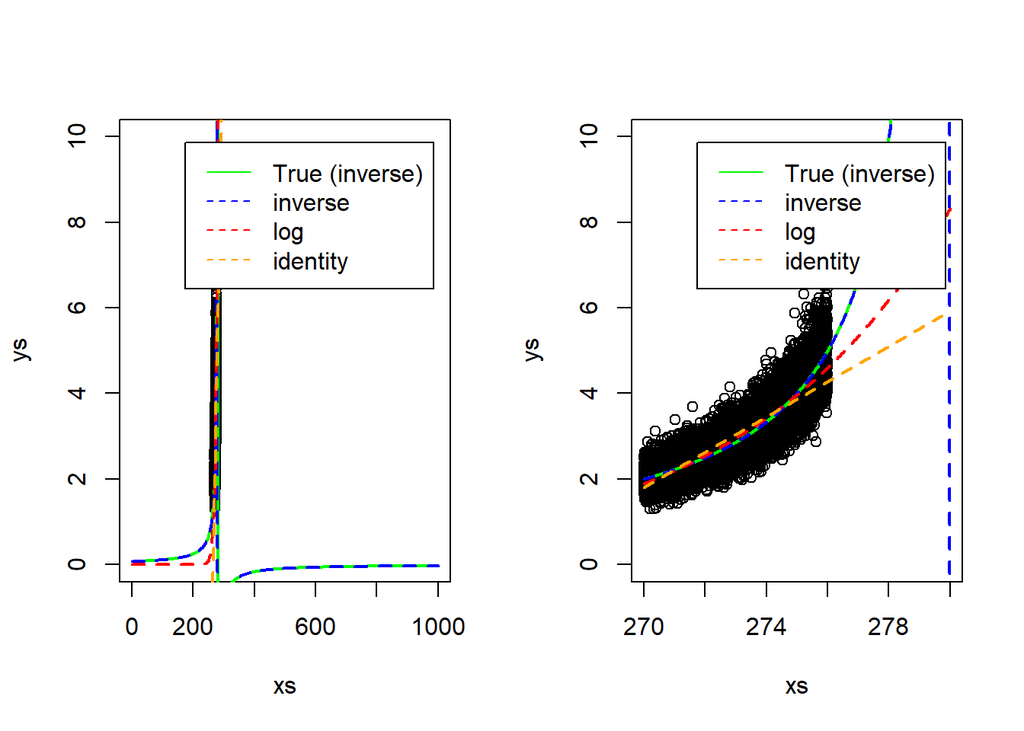

```r
par(mfrow=c(1,2))

plot(xs,ys,xlim=c(0,1000),ylim=c(0,10))
#plot data
#add true line
xspreds<-seq(0,1000,length=npred)
points(xspreds,(1/(int+slope*xspreds)),type="l",col="green",lwd=2)

preds<-predict(glm1.i,newdata = data.frame(length=xspreds),type="response")
#add fitted values
points(xspreds,preds,type="l",col="blue",lwd=2,lty=2)
# IDENTITY LINK
preds<-predict(glm2,newdata = data.frame(length=xspreds),type="response")
#add fitted values
points(xspreds,preds,type="l",col="red",lwd=2,lty=2)
# IDENTITY LINK
preds<-predict(glm3,newdata = data.frame(length=xspreds),type="response")
#add fitted values
points(xspreds,preds,type="l",col="orange",lwd=2,lty=2)
legend("topright",legend=c("True (inverse)","inverse","log","identity"),col=c("green","blue","red","orange"),lty=c(1,2,2,2),inset=0.05)


plot(xs,ys,xlim=c(270,280),ylim=c(0,10))
#plot data
#add true line
xspreds<-seq(270,280,length=npred)
points(xspreds,(1/(int+slope*xspreds)),type="l",col="green",lwd=2)

preds<-predict(glm1.i,newdata = data.frame(length=xspreds),type="response")
#add fitted values
points(xspreds,preds,type="l",col="blue",lwd=2,lty=2)
# IDENTITY LINK
preds<-predict(glm2,newdata = data.frame(length=xspreds),type="response")
#add fitted values
points(xspreds,preds,type="l",col="red",lwd=2,lty=2)
# IDENTITY LINK
preds<-predict(glm3,newdata = data.frame(length=xspreds),type="response")
#add fitted values
points(xspreds,preds,type="l",col="orange",lwd=2,lty=2)
legend("topright",legend=c("True (inverse)","inverse","log","identity"),col=c("green","blue","red","orange"),lty=c(1,2,2,2),inset=0.05)
```

# A comparison for illustration with real data

For illustration, we consider the well known data cars from R package MASS

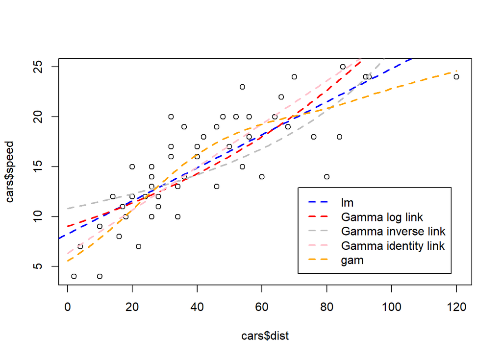

```r
data(cars)
plot(cars$speed~cars$dist)

lm1<-lm(speed~dist,data=cars)
abline(lm1,col="blue",lty=2,lwd=2)


glm2<- glm(speed~dist,data=cars,family=Gamma(link="log"))
#just to illustrate abline can't be used with a glm object
#abline(glm2,col="green")


seqxs <- 0:120
preds<-predict(glm2,newdata = data.frame(dist=seqxs),type="response")
points(seqxs,preds,col="red",type="l",lty=2,lwd=2)


glm3<- glm(speed~dist,data=cars,family=Gamma(link="inverse"))
preds<-predict(glm3,newdata = data.frame(dist=seqxs),type="response")
points(seqxs,preds,col="grey",type="l",lty=2,lwd=2)

glm4<- glm(speed~dist,data=cars,family=Gamma(link="identity"))
preds<-predict(glm4,newdata = data.frame(dist=seqxs),type="response")
points(seqxs,preds,col="pink",type="l",lty=2,lwd=2)

library(mgcv)
gam1<- gam(speed~s(dist),data=cars,family=Gamma(link="log"))
preds<-predict(gam1,newdata = data.frame(dist=seqxs),type="response")
points(seqxs,preds,col="orange",type="l",lty=2,lwd=2)

legend("bottomright",legend=c("lm","Gamma log link","Gamma inverse link","Gamma identity link","gam"),col=c("blue","red","grey","pink","orange"),lty=c(2,2,2,2,2),lwd=2,inset=0.05)
```

For comparison, the AIC of all models

```r
AIC(lm1,glm2,glm3,glm4,gam1)
```

```
##            df      AIC
## lm1  3.000000 260.7755
## glm2 3.000000 279.5515
## glm3 3.000000 288.6131
## glm4 3.000000 267.0432
## gam1 5.373995 261.3574
```

```r
summary(glm4)
```

```
##
## Call:
## glm(formula = speed ~ dist, family = Gamma(link = "identity"),
##     data = cars)
##
## Coefficients:
##             Estimate Std. Error t value          Pr(>|t|)
## (Intercept)  6.33233    0.69683   9.087 0.000000000005277 ***
## dist         0.21612    0.02038  10.603 0.000000000000036 ***
## ---
## Signif. codes:  0 '***' 0.001 '**' 0.01 '*' 0.05 '.' 0.1 ' ' 1
##
## (Dispersion parameter for Gamma family taken to be 0.04942207)
##
##     Null deviance: 7.2361  on 49  degrees of freedom
## Residual deviance: 2.6176  on 48  degrees of freedom
## AIC: 267.04
##
## Number of Fisher Scoring iterations: 8
```

with the inverse link

```r
summary(glm3)
```

```
##
## Call:
## glm(formula = speed ~ dist, family = Gamma(link = "inverse"),
##     data = cars)
##
## Coefficients:
##                Estimate  Std. Error t value             Pr(>|t|)
## (Intercept)  0.09240566  0.00482149  19.165 < 0.0000000000000002 ***
## dist        -0.00054967  0.00007137  -7.702       0.000000000624 ***
## ---
## Signif. codes:  0 '***' 0.001 '**' 0.01 '*' 0.05 '.' 0.1 ' ' 1
##
## (Dispersion parameter for Gamma family taken to be 0.06760366)
##
##     Null deviance: 7.2361  on 49  degrees of freedom
## Residual deviance: 4.0109  on 48  degrees of freedom
## AIC: 288.61
##
## Number of Fisher Scoring iterations: 4
```

# Resources to explore further

Some reources to explor further check if improving this material at some point.

- A gentle introduction to gamma regression can be found here: https://data.library.virginia.edu/getting-started-with-gamma-regression/ and the authors provide also a dataset of house prices which can be used to illustrate Gamma regression. I have saved a copy of the data hosted here http://static.lib.virginia.edu/statlab/materials/data/alb_homes.csv in case I want to use it later and it is removed from the site.
- https://rpubs.com/jwesner/gamma_glm - Fit and interpret a Bayesian Generalized Linear Model with a Gamma likelihood in `brms()`, by Jeff Wesner. Very nice worked example

https://seananderson.ca/2014/04/08/gamma-glms/ - A nice intro by https://seananderson.ca/. One should never forget: “There are multiple ways to parameterize the Gamma distribution, so it’s important to pay attention when moving between languages and functions.”

- about link functions in the Gamma, see https://stats.stackexchange.com/questions/202570/link-function-in-a-gamma-distribution-glm and https://stats.stackexchange.com/questions/484366/gamma-glm-why-log-link-is-more-common-than-canonical-link
- If linking to log-log weight-length regressions, e.g. see https://stats.stackexchange.com/questions/77579/log-linked-gamma-glm-vs-log-linked-gaussian-glm-vs-log-transformed-lm or https://stats.stackexchange.com/questions/47840/linear-model-with-log-transformed-response-vs-generalized-linear-model-with-log. Relation with log-normal GLM:

# References

Douma, J.C. & Weedon, J.T. (2019). [Analysing continuous proportions in ecology and evolution: A practical introduction to beta and dirichlet regression](https://doi.org/10.1111/2041-210x.13234) (D. Warton, Ed.). *Methods in Ecology and Evolution*, **10**, 1412–1430.

Lindsey, J.K. & Jones, B. (1998). Choosing among generalized linear models applied to medical data. *Statistics in Medicine*, **17**, 59–68.